# Background

## Hierarchical Clustering

```python
# Let's see unique values
cols = bc.columns

for col in cols:
    print("Unique values in the column '{}' are \n\n".format(col), bc[col].unique())
    print("-" * 100)
```

[output not shown]

[output cut: 607 more lines]

[output not shown]

```python
cluster_cols = [
'Ticker Symbol',
'Company',
'GICS Sector',
'GICS Sub Industry',
'Current Price',
'Price Change',
'Volatility',
'ROE',
'Cash Ratio',
'Net Cash Flow',
'Net Income',
'Earnings Per Share',
'Estimated Shares Outstanding',
'P/E Ratio',
'P/B Ratio',
]
```

```python
bc1 = bc[cluster_cols].copy()
bc1.head()
```

|  | Ticker Symbol | Company | GICS Sector | GICS Sub Industry | Current Price | Price Change | Volatility | ROE | Cash Ratio | Net Cash Flow | Net Income | Earnings Per Share | Estimated Shares Outstanding | P/E Ratio | P/B Ratio |
| --- | --- | --- | --- | --- | --- | --- | --- | --- | --- | --- | --- | --- | --- | --- | --- |
| 0 | AAL | American Airlines Group | Industrials | Airlines | 42.349998 | 9.999995 | 1.687151 | 135 | 51 | -604000000 | 7610000000 | 11.39 | 6.681299e+08 | 3.718174 | -8.784219 |
| 1 | ABBV | AbbVie | Health Care | Pharmaceuticals | 59.240002 | 8.339433 | 2.197887 | 130 | 77 | 51000000 | 5144000000 | 3.15 | 1.633016e+09 | 18.806350 | -8.750068 |
| 2 | ABT | Abbott Laboratories | Health Care | Health Care Equipment | 44.910000 | 11.301121 | 1.273646 | 21 | 67 | 938000000 | 4423000000 | 2.94 | 1.504422e+09 | 15.275510 | -0.394171 |
| 3 | ADBE | Adobe Systems Inc | Information Technology | Application Software | 93.940002 | 13.977195 | 1.357679 | 9 | 180 | -240840000 | 629551000 | 1.26 | 4.996437e+08 | 74.555557 | 4.199651 |
| 4 | ADI | Analog Devices, Inc. | Information Technology | Semiconductors | 55.320000 | -1.827858 | 1.701169 | 14 | 272 | 315120000 | 696878000 | 0.31 | 2.247994e+09 | 178.451613 | 1.059810 |

```python
bc1.describe(include="all").T
```

|  | count | unique | top | freq | mean | std | min | 25% | 50% | 75% | max |
| --- | --- | --- | --- | --- | --- | --- | --- | --- | --- | --- | --- |
| Ticker Symbol | 340 | 340 | AAL | 1 | NaN | NaN | NaN | NaN | NaN | NaN | NaN |
| Company | 340 | 340 | 3M Company | 1 | NaN | NaN | NaN | NaN | NaN | NaN | NaN |
| GICS Sector | 340 | 11 | Industrials | 53 | NaN | NaN | NaN | NaN | NaN | NaN | NaN |
| GICS Sub Industry | 340 | 104 | Oil & Gas Exploration & Production | 16 | NaN | NaN | NaN | NaN | NaN | NaN | NaN |
| Current Price | 340.0 | NaN | NaN | NaN | 80.862345 | 98.055086 | 4.5 | 38.555 | 59.705 | 92.880001 | 1274.949951 |
| Price Change | 340.0 | NaN | NaN | NaN | 4.078194 | 12.006338 | -47.129693 | -0.939484 | 4.819505 | 10.695493 | 55.051683 |
| Volatility | 340.0 | NaN | NaN | NaN | 1.525976 | 0.591798 | 0.733163 | 1.134878 | 1.385593 | 1.695549 | 4.580042 |
| ROE | 340.0 | NaN | NaN | NaN | 39.597059 | 96.547538 | 1.0 | 9.75 | 15.0 | 27.0 | 917.0 |
| Cash Ratio | 340.0 | NaN | NaN | NaN | 70.023529 | 90.421331 | 0.0 | 18.0 | 47.0 | 99.0 | 958.0 |
| Net Cash Flow | 340.0 | NaN | NaN | NaN | 55537620.588235 | 1946365312.175789 | -11208000000.0 | -193906500.0 | 2098000.0 | 169810750.0 | 20764000000.0 |
| Net Income | 340.0 | NaN | NaN | NaN | 1494384602.941176 | 3940150279.327937 | -23528000000.0 | 352301250.0 | 707336000.0 | 1899000000.0 | 24442000000.0 |
| Earnings Per Share | 340.0 | NaN | NaN | NaN | 2.776662 | 6.587779 | -61.2 | 1.5575 | 2.895 | 4.62 | 50.09 |
| Estimated Shares Outstanding | 340.0 | NaN | NaN | NaN | 577028337.754029 | 845849595.417695 | 27672156.86 | 158848216.1 | 309675137.8 | 573117457.325 | 6159292035.0 |
| P/E Ratio | 340.0 | NaN | NaN | NaN | 32.612563 | 44.348731 | 2.935451 | 15.044653 | 20.819876 | 31.764755 | 528.039074 |
| P/B Ratio | 340.0 | NaN | NaN | NaN | -1.718249 | 13.966912 | -76.119077 | -4.352056 | -1.06717 | 3.917066 | 129.064585 |

```python
#scaling of dat
sc = StandardScaler()
subset_scaled_df = pd.DataFrame(
    sc.fit_transform(bc1.drop(["Ticker Symbol", "GICS Sector","GICS Sub Industry","Company"], axis=1)),
    columns=bc1.drop(["Ticker Symbol", "GICS Sector","GICS Sub Industry","Company"], axis=1).columns,
)
subset_scaled_df.head()
```

|  | Current Price | Price Change | Volatility | ROE | Cash Ratio | Net Cash Flow | Net Income | Earnings Per Share | Estimated Shares Outstanding | P/E Ratio | P/B Ratio |
| --- | --- | --- | --- | --- | --- | --- | --- | --- | --- | --- | --- |
| 0 | -0.393341 | 0.493950 | 0.272749 | 0.989601 | -0.210698 | -0.339355 | 1.554415 | 1.309399 | 0.107863 | -0.652487 | -0.506653 |
| 1 | -0.220837 | 0.355439 | 1.137045 | 0.937737 | 0.077269 | -0.002335 | 0.927628 | 0.056755 | 1.250274 | -0.311769 | -0.504205 |
| 2 | -0.367195 | 0.602479 | -0.427007 | -0.192905 | -0.033488 | 0.454058 | 0.744371 | 0.024831 | 1.098021 | -0.391502 | 0.094941 |
| 3 | 0.133567 | 0.825696 | -0.284802 | -0.317379 | 1.218059 | -0.152497 | -0.219816 | -0.230563 | -0.091622 | 0.947148 | 0.424333 |
| 4 | -0.260874 | -0.492636 | 0.296470 | -0.265515 | 2.237018 | 0.133564 | -0.202703 | -0.374982 | 1.978399 | 3.293307 | 0.199196 |

```python
# list of distance metrics
distance_metrics = ["euclidean", "chebyshev", "mahalanobis", "cityblock"]

# list of linkage methods
linkage_methods = ["single", "complete", "average", "weighted"]

high_cophenet_corr = 0
high_dm_lm = [0, 0]

for dm in distance_metrics:
    for lm in linkage_methods:
        Z = linkage(subset_scaled_df, metric=dm, method=lm)
        c, coph_dists = cophenet(Z, pdist(subset_scaled_df))
        print(
            "Cophenetic correlation for {} distance and {} linkage is {}.".format(
                dm.capitalize(), lm, c
            )
        )
        if high_cophenet_corr < c:
            high_cophenet_corr = c
            high_dm_lm[0] = dm
            high_dm_lm[1] = lm
```

```
Cophenetic correlation for Euclidean distance and single linkage is 0.9232271494002922.
Cophenetic correlation for Euclidean distance and complete linkage is 0.7873280186580672.
Cophenetic correlation for Euclidean distance and average linkage is 0.9422540609560814.
Cophenetic correlation for Euclidean distance and weighted linkage is 0.8693784298129404.
Cophenetic correlation for Chebyshev distance and single linkage is 0.9062538164750717.
Cophenetic correlation for Chebyshev distance and complete linkage is 0.598891419111242.
Cophenetic correlation for Chebyshev distance and average linkage is 0.9338265528030499.
Cophenetic correlation for Chebyshev distance and weighted linkage is 0.9127355892367.
Cophenetic correlation for Mahalanobis distance and single linkage is 0.9259195530524589.
Cophenetic correlation for Mahalanobis distance and complete linkage is 0.7925307202850003.
Cophenetic correlation for Mahalanobis distance and average linkage is 0.9247324030159737.
Cophenetic correlation for Mahalanobis distance and weighted linkage is 0.8708317490180426.
Cophenetic correlation for Cityblock distance and single linkage is 0.9334186366528574.
Cophenetic correlation for Cityblock distance and complete linkage is 0.7375328863205818.
Cophenetic correlation for Cityblock distance and average linkage is 0.9302145048594667.
Cophenetic correlation for Cityblock distance and weighted linkage is 0.731045513520281.
```

```python
# printing the combination of distance metric and linkage method with the highest cophenetic correlation
print(
    "Highest cophenetic correlation is {}, which is obtained with {} distance and {} linkage.".format(
        high_cophenet_corr, high_dm_lm[0].capitalize(), high_dm_lm[1]
    )
)
```

```
Highest cophenetic correlation is 0.9422540609560814, which is obtained with Euclidean distance and average linkage.
```

```python
# list of linkage methods
linkage_methods = ["single", "complete", "average", "centroid", "ward", "weighted"]

high_cophenet_corr = 0
high_dm_lm = [0, 0]

for lm in linkage_methods:
    Z = linkage(subset_scaled_df, metric="euclidean", method=lm)
    c, coph_dists = cophenet(Z, pdist(subset_scaled_df))
    print("Cophenetic correlation for {} linkage is {}.".format(lm, c))
    if high_cophenet_corr < c:
        high_cophenet_corr = c
        high_dm_lm[0] = "euclidean"
        high_dm_lm[1] = lm
```

```
Cophenetic correlation for single linkage is 0.9232271494002922.
Cophenetic correlation for complete linkage is 0.7873280186580672.
Cophenetic correlation for average linkage is 0.9422540609560814.
Cophenetic correlation for centroid linkage is 0.9314012446828154.
Cophenetic correlation for ward linkage is 0.7101180299865353.
Cophenetic correlation for weighted linkage is 0.8693784298129404.
```

```python
# printing the combination of distance metric and linkage method with the highest cophenetic correlation
print(
    "Highest cophenetic correlation is {}, which is obtained with {} linkage.".format(
        high_cophenet_corr, high_dm_lm[1]
    )
)
```

```
Highest cophenetic correlation is 0.9422540609560814, which is obtained with average linkage.
```

#### Observations

We see that the cophenetic correlation is maximum with Euclidean distance and average linkage.

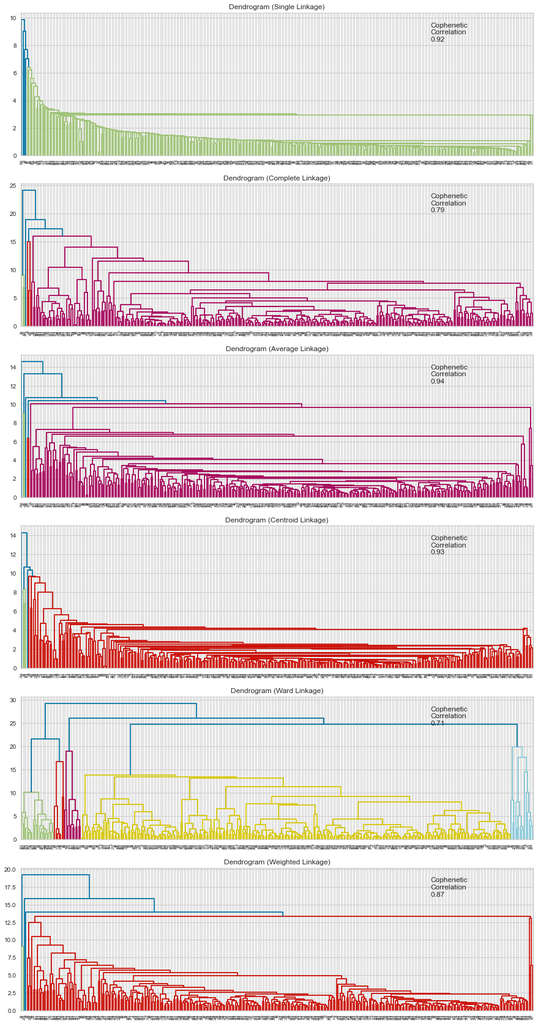

```python
# list of linkage methods
linkage_methods = ["single", "complete", "average", "centroid", "ward", "weighted"]

# lists to save results of cophenetic correlation calculation
compare_cols = ["Linkage", "Cophenetic Coefficient"]

# to create a subplot image
fig, axs = plt.subplots(len(linkage_methods), 1, figsize=(15, 30))

# We will enumerate through the list of linkage methods above
# For each linkage method, we will plot the dendrogram and calculate the cophenetic correlation
for i, method in enumerate(linkage_methods):
    Z = linkage(subset_scaled_df, metric="euclidean", method=method)

    dendrogram(Z, ax=axs[i])
    axs[i].set_title(f"Dendrogram ({method.capitalize()} Linkage)")

    coph_corr, coph_dist = cophenet(Z, pdist(subset_scaled_df))
    axs[i].annotate(
        f"Cophenetic\nCorrelation\n{coph_corr:0.2f}",
        (0.80, 0.80),
        xycoords="axes fraction",
    )
```

```python
HCmodel = AgglomerativeClustering(n_clusters=5, affinity="euclidean", linkage="average")
HCmodel.fit(subset_scaled_df)
```

```
AgglomerativeClustering(linkage='average', n_clusters=5)
```

```python
subset_scaled_df["HC_Clusters"] = HCmodel.labels_
bc1["HC_Clusters"] = HCmodel.labels_
```

### Cluster Profiling (Average Linking)

```python
cluster_profile = bc1.groupby("HC_Clusters").mean()
```

```python
cluster_profile["count_in_each_segments"] = (
    bc1.groupby("HC_Clusters")["Current Price"].count().values
)
```

```python
# let's see the names of the companies in each cluster
for cl in bc1["HC_Clusters"].unique():
    print("In cluster {}, the following companies are present:".format(cl))
    print(bc1[bc1["HC_Clusters"] == cl]["Company"].unique())
    print()
```

```
In cluster 0, the following companies are present:
['American Airlines Group', 'AbbVie', 'Abbott Laboratories', 'Adobe Systems Inc', 'Analog Devices, Inc.', ..., 'Yahoo Inc.', 'Yum! Brands Inc', 'Zimmer Biomet Holdings', 'Zions Bancorp', 'Zoetis']
Length: 334
Categories (334, object): ['American Airlines Group', 'AbbVie', 'Abbott Laboratories', 'Adobe Systems Inc', ..., 'Yum! Brands Inc', 'Zimmer Biomet Holdings', 'Zions Bancorp', 'Zoetis']

In cluster 2, the following companies are present:
['Apache Corporation', 'Chesapeake Energy']
Categories (2, object): ['Apache Corporation', 'Chesapeake Energy']

In cluster 1, the following companies are present:
['Bank of America Corp', 'Intel Corp.']
Categories (2, object): ['Bank of America Corp', 'Intel Corp.']

In cluster 3, the following companies are present:
['Facebook']
Categories (1, object): ['Facebook']

In cluster 4, the following companies are present:
['Priceline.com Inc']
Categories (1, object): ['Priceline.com Inc']
```

We see that there are 2 clusters of one company, 2 cluster of two companies, and all the other countries are grouped into another cluster. This clustering does not look good as the clusters do not have enough variability.

Let us try using Ward linkage as it has more distinct and separated clusters (as seen from it's dendrogram before). 6 appears to be the appropriate number of clusters from the dendrogram for Ward linkage.

```python
HCmodel = AgglomerativeClustering(n_clusters=6, affinity="euclidean", linkage="ward")
HCmodel.fit(subset_scaled_df)
```

```
AgglomerativeClustering(n_clusters=6)
```

```python
subset_scaled_df["HC_Clusters"] = HCmodel.labels_
bc1["HC_Clusters"] = HCmodel.labels_
```

### Cluster Profiling (Ward Linking)

```python
cluster_profile = bc1.groupby("HC_Clusters").mean()
```

```python
cluster_profile["count_in_each_segments"] = (
    bc1.groupby("HC_Clusters")["Current Price"].count().values
)
```

```python
# let's see the names of the countries in each cluster
for cl in bc1["HC_Clusters"].unique():
    print(
        "The",
        bc1[bc1["HC_Clusters"] == cl]["Company"].nunique(),
        "countries in cluster",
        cl,
        "are:",
    )
    print(bc1[bc1["HC_Clusters"] == cl]["Company"].unique())
    print("-" * 100, "\n")
```

```
The 275 countries in cluster 3 are:
['American Airlines Group', 'AbbVie', 'Abbott Laboratories', 'Analog Devices, Inc.', 'Archer-Daniels-Midland Co', ..., 'Xylem Inc.', 'Yum! Brands Inc', 'Zimmer Biomet Holdings', 'Zions Bancorp', 'Zoetis']
Length: 275
Categories (275, object): ['American Airlines Group', 'AbbVie', 'Abbott Laboratories', 'Analog Devices, Inc.', ..., 'Yum! Brands Inc', 'Zimmer Biomet Holdings', 'Zions Bancorp', 'Zoetis']
----------------------------------------------------------------------------------------------------

The 23 countries in cluster 2 are:
['Adobe Systems Inc', 'Alliance Data Systems', 'Applied Materials Inc', 'Amgen Inc', 'Broadcom', ..., 'TripAdvisor', 'Vertex Pharmaceuticals Inc', 'Waters Corporation', 'Wynn Resorts Ltd', 'Yahoo Inc.']
Length: 23
Categories (23, object): ['Adobe Systems Inc', 'Alliance Data Systems', 'Applied Materials Inc', 'Amgen Inc', ..., 'Vertex Pharmaceuticals Inc', 'Waters Corporation', 'Wynn Resorts Ltd', 'Yahoo Inc.']
----------------------------------------------------------------------------------------------------

The 7 countries in cluster 1 are:
['Allegion', 'Apache Corporation', 'Chesapeake Energy', 'Charter Communications', 'Colgate-Palmolive', 'Kimberly-Clark', 'S&P Global, Inc.']
Categories (7, object): ['Allegion', 'Apache Corporation', 'Chesapeake Energy', 'Charter Communications', 'Colgate-Palmolive', 'Kimberly-Clark', 'S&P Global, Inc.']
----------------------------------------------------------------------------------------------------

The 4 countries in cluster 0 are:
['Alexion Pharmaceuticals', 'Amazon.com Inc', 'Netflix Inc.', 'Priceline.com Inc']
Categories (4, object): ['Alexion Pharmaceuticals', 'Amazon.com Inc', 'Netflix Inc.', 'Priceline.com Inc']
----------------------------------------------------------------------------------------------------

The 22 countries in cluster 4 are:
['Anadarko Petroleum Corp', 'Baker Hughes Inc', 'Cabot Oil & Gas', 'Concho Resources', 'Devon Energy Corp.', ..., 'Spectra Energy Corp.', 'Southwestern Energy', 'Teradata Corp.', 'Williams Cos.', 'Cimarex Energy']
Length: 22
Categories (22, object): ['Anadarko Petroleum Corp', 'Baker Hughes Inc', 'Cabot Oil & Gas', 'Concho Resources', ..., 'Southwestern Energy', 'Teradata Corp.', 'Williams Cos.', 'Cimarex Energy']
----------------------------------------------------------------------------------------------------

The 9 countries in cluster 5 are:
['Citigroup Inc.', 'Ford Motor', 'JPMorgan Chase & Co.', 'Coca Cola Company', 'Pfizer Inc.', 'AT&T Inc', 'Verizon Communications', 'Wells Fargo', 'Exxon Mobil Corp.']
Categories (9, object): ['Citigroup Inc.', 'Ford Motor', 'JPMorgan Chase & Co.', 'Coca Cola Company', ..., 'AT&T Inc', 'Verizon Communications', 'Wells Fargo', 'Exxon Mobil Corp.']
----------------------------------------------------------------------------------------------------
```

```python
# lets display cluster profile
cluster_profile.style.highlight_max(color="lightgreen", axis=0)
```

| HC_Clusters | Current Price | Price Change | Volatility | ROE | Cash Ratio | Net Cash Flow | Net Income | Earnings Per Share | Estimated Shares Outstanding | P/E Ratio | P/B Ratio | count_in_each_segments |
| --- | --- | --- | --- | --- | --- | --- | --- | --- | --- | --- | --- | --- |
| 0 | 563.992491 | 17.235667 | 1.839399 | 10.250000 | 125.500000 | 105834000.000000 | 853500250.000000 | 13.085000 | 287806305.492500 | 307.105187 | -4.254889 | 4 |
| 1 | 84.355716 | 3.854981 | 1.827670 | 633.571429 | 33.571429 | -568400000.000000 | -4968157142.857142 | -10.841429 | 398169036.442857 | 42.284541 | -11.589502 | 7 |
| 2 | 152.566666 | 14.908086 | 1.769506 | 24.434783 | 281.913043 | 1747221304.347826 | 1866621956.521739 | 3.802174 | 759756952.867391 | 38.674023 | 16.027369 | 23 |
| 3 | 72.421687 | 4.563230 | 1.403434 | 25.218182 | 55.014545 | 72801872.727273 | 1572467469.090909 | 3.728564 | 445003946.148763 | 24.188244 | -2.966949 | 275 |
| 4 | 36.440455 | -16.073408 | 2.832884 | 57.500000 | 42.409091 | -472834090.909091 | -3161045227.272727 | -8.005000 | 514367806.201818 | 85.555682 | 0.836839 | 22 |
| 5 | 46.672222 | 5.166566 | 1.079367 | 25.000000 | 58.333333 | -3040666666.666667 | 14848444444.444445 | 3.435556 | 4564959946.222222 | 15.596051 | -6.354193 | 9 |

We will look into clusters 2, 3, and 4 as they have the highest number of data points in them.

- **Cluster 2**
  - There are 23 companies in this cluster.
  - They have the second highest average share price with the second highest positive price change.
  - They have an average ROE with the highest net cash flow indicating that the companies are doing very well for their share holders as indicated by the second highest earning per share.
- **Cluster 3**
  - There are 275 companies in this cluster.
  - They have the relatively high average share price with a positive price change and a normal volatility.
  - They have a comparatively high ROE with a positive net cash flow indicating that the companies are well as evidenced by the positive earnings per share.
- **Cluster 4**
  - There are 22 countries in this cluster.
  - They have the lowest average share price with a negative price change.
  - They have the second highest ROE with a negative net cash flow indicating that the companies are not making enough cash and have highest costs than their revenue. They also have a negative earnings per share

### Dimensionality Reduction using PCA for visualization

```python
#setting the number of components to 2
pca = PCA(n_components=2)

# transforming data and storing results in a dataframe
X_reduced_pca = pca.fit_transform(subset_scaled_df)
reduced_df_pca = pd.DataFrame(
    data=X_reduced_pca, columns=["Component 1", "Component 2"]
)
```

```python
# checking the amount of variance explained
pca.explained_variance_ratio_.sum()
```

```
0.3755243247007718
```

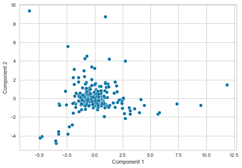

```python
sns.scatterplot(data=reduced_df_pca, x="Component 1", y="Component 2")
```

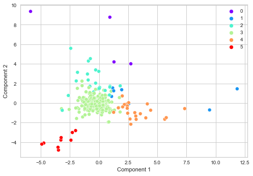

```python
sns.scatterplot(
    data=reduced_df_pca,
    x="Component 1",
    y="Component 2",
    hue=bc1["HC_Clusters"],
    palette="rainbow",
)
plt.legend(bbox_to_anchor=(1, 1))
```

# K-means vs Hierarchical Clustering

# Conclusion and Recommendation

## Conclusion

Based on the analysis done on the data, these are the groups with the highest amount of data. Below is a short summary of them:

- **Cluster 2**
  - There are 23 companies in this cluster.
  - They have the second highest average share price with the second highest positive price change.
  - They have an average ROE with the highest net cash flow indicating that the companies are doing very well for their share holders as indicated by the second highest earning per share.
- **Cluster 3**
  - There are 275 companies in this cluster.
  - They have the relatively high average share price with a positive price change and a normal volatility.
  - They have a comparatively high ROE with a positive net cash flow indicating that the companies are well as evidenced by the positive earnings per share.
- **Cluster 4**
  - There are 22 countries in this cluster.
  - They have the lowest average share price with a negative price change.
  - They have the second highest ROE with a negative net cash flow indicating that the companies are not making enough cash and have highest costs than their revenue. They also have a negative earnings per share

## Recommendations

1. Though none of the clusters chosen as representations have the highest *Current Price*, for investment purposes, **Cluster 2** has the best chance of returing the investment as evidenced by the various factors such as it having the second highest *average share price*, the highest *net cash flow* and the second highest *earnings per share*.
2. As there are 23 companies in the cluster, it will provide a wide enough range for a diversified enough portfolio if one should so wish.
3. The next best cluster to look at is **Cluster 3** based on the above mentioned factors